# Complex Data - Homework 2 - Błażej Wiórek

### Wald test

We are given hypothesis $H_0: \beta_3 = 0$ vs $H_1: \beta_3 \neq 0$. The univariate Wald statistic:
$$Z = \frac{\hat{\beta}_3}{\sqrt{\hat{Var}(\hat{\beta_3})}} \sim N(0, 1) \text{ under } H_0$$

In matrix notation it can be written as:
$$Z = \frac{L^T\hat{\beta}}{\sqrt{L^T \hat{Cov}(\hat{\beta}) L}}$$

Where:

- $L$ is test matrix
- $\hat{Cov}(\hat{\beta})$ is an estimate of covariance matrix of $\hat{\beta}$
- $H_0: L^T\beta = 0$

If the test is defined as it was done in the question (univariate Wald test), then we have that:
$$L = (0, 0, 1, 0)^T$$

If the global hypothesis $H_0: L^T\beta=0$ is of interest, then:
$$L =
\begin{pmatrix}
1 & 0 & 0 & 0 \\
0 & 1 & 0 & 0 \\
0 & 0 & 1 & 0 \\
0 & 0 & 0 & 1
\end{pmatrix}$$

### Likelihood ratio test

Regression model for the lead exposure:
$$Y_{ij} = \beta_1 + \beta_2 X_{2ij} + \beta_3 X_{3ij} + \beta_4 X_{4ij} + e_{ij}$$
where $i \in \{1, ..., 50\}$, $j \in \{1, ..., 4\}$ and additionally $X_{kij}$ is indicator of k-th week, where $k \in \{1, 4, 6\}$ excluding baseline.

If $H_0: \beta_2 = \beta_3 = \beta_4 = 0$, then reduced model from alternative hypothesis is $Y_{ij} = \beta_1 + \epsilon_{ij}$. The test statistics is given as:
$$LRT = 2(\hat{l}_{full} - \hat{l}_{reduced}) \sim \chi^2_r \text{ under } H_0$$
Degrees of freedom of LRT statistic ($r$) is the difference between number of parameters in the full and reduced model. In case of give example we have that $r = 4 - 1 = 3$. In order to carry this procedure the models must be fitted with MLE procedure. It happens because when model is fitted with REML, then REML likelhoods don’t involve the regression parameters.

### Working with moo dataset

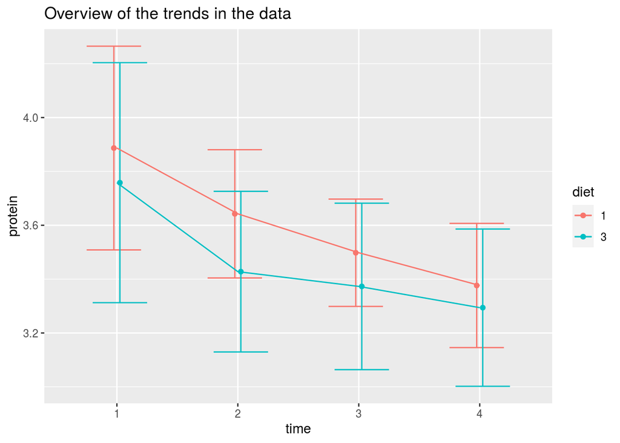

```
## Generalized least squares fit by REML
##   Model: protein ~ diet * time
##   Data: moo_data
##        AIC      BIC    logLik
##   79.75536 139.0348 -21.87768
##
## Correlation Structure: General
##  Formula: ~1 | id
##  Parameter estimate(s):
##  Correlation:
##   1     2     3
## 2 0.436
## 3 0.428 0.579
## 4 0.295 0.546 0.644
## Variance function:
##  Structure: Different standard deviations per stratum
##  Formula: ~1 | time
##  Parameter estimates:
##         1         2         3         4
## 1.0000000 0.6530749 0.6312472 0.6367197
##
## Coefficients:
##                 Value  Std.Error  t-value p-value
## (Intercept)  3.885969 0.08297114 46.83519  0.0000
## diet3       -0.127821 0.11517354 -1.10981  0.2684
## time2       -0.247724 0.07715913 -3.21056  0.0015
## time3       -0.387677 0.07681337 -5.04700  0.0000
## time4       -0.510641 0.08388310 -6.08753  0.0000
## diet3:time2 -0.082646 0.10686508 -0.77337  0.4402
## diet3:time3  0.002492 0.10666597  0.02336  0.9814
## diet3:time4  0.046567 0.11663957  0.39923  0.6901
##
##  Correlation:
##             (Intr) diet3  time2  time3  time4  dt3:t2 dt3:t3
## diet3       -0.720
## time2       -0.768  0.553
## time3       -0.788  0.567  0.792
## time4       -0.800  0.576  0.797  0.850
## diet3:time2  0.554 -0.770 -0.722 -0.572 -0.575
## diet3:time3  0.567 -0.788 -0.570 -0.720 -0.612  0.794
## diet3:time4  0.575 -0.800 -0.573 -0.611 -0.719  0.800  0.851
##
## Standardized residuals:
##         Min          Q1         Med          Q3         Max
## -2.57344143 -0.63136629  0.05551414  0.67999624  2.67112148
##
## Residual standard error: 0.415066
## Degrees of freedom: 207 total; 199 residual
```

It’s worth to notice that the mean of proteins for first measurement is considered as a baseline. Another interesting observation is that there are no reasons to claim the difference between the trajectories as we fail to reject the hypothesis $diet3 = diet3*time2 = diet3*time3=diet3*time4 = 0$.

It turns out that testing procedures for such models can be automated with anova function. When only one fitted model object is present, then anova output is based on Wald test.

```
## Denom. DF: 199
##             numDF   F-value p-value
## (Intercept)     1 12205.024  <.0001
## diet            1     4.584  0.0335
## time            3    24.999  <.0001
## diet:time       3     1.159  0.3265
```

The results contain information about two tests for main effects (row 2 and 3) and test for parallelism (row 4)

Above tests lays foundations for the ideas of model simplification. For instance we can safely assume that there is no group-by-time interaction and diet-time interaction, so they can be removed.

```
## Generalized least squares fit by REML
##   Model: protein ~ diet + time
##   Data: moo_data
##        AIC      BIC    logLik
##   66.97093 116.5949 -18.48546
##
## Correlation Structure: General
##  Formula: ~1 | id
##  Parameter estimate(s):
##  Correlation:
##   1     2     3
## 2 0.436
## 3 0.433 0.580
## 4 0.300 0.530 0.646
## Variance function:
##  Structure: Different standard deviations per stratum
##  Formula: ~1 | time
##  Parameter estimates:
##         1         2         3         4
## 1.0000000 0.6631816 0.6341010 0.6425259
##
## Coefficients:
##                 Value  Std.Error  t-value p-value
## (Intercept)  3.889789 0.06578316 59.13047  0.0000
## diet3       -0.134982 0.06259702 -2.15637  0.0322
## time2       -0.291760 0.05318256 -5.48602  0.0000
## time3       -0.386526 0.05276886 -7.32488  0.0000
## time4       -0.486574 0.05780775 -8.41711  0.0000
##
##  Correlation:
##       (Intr) diet3  time2  time3
## diet3 -0.495
## time2 -0.662 -0.002
## time3 -0.683  0.002  0.791
## time4 -0.692  0.002  0.788  0.849
##
## Standardized residuals:
##         Min          Q1         Med          Q3         Max
## -2.58314986 -0.65286155  0.04483419  0.68628560  2.76287611
##
## Residual standard error: 0.4122125
## Degrees of freedom: 207 total; 202 residual
```

Let’s call anova function one more time on reduced model:

```
## Denom. DF: 202
##             numDF   F-value p-value
## (Intercept)     1 12182.237  <.0001
## diet            1     4.541  0.0343
## time            3    25.184  <.0001
```

Another test that might be usefull is likelihood ratio test, because the latest model is the reduced version of the model with interaction terms. If we want to test the importance of the interaction terms we get the following results:

```
##                          Model df      AIC       BIC    logLik   Test  L.Ratio
## moo.unrestr_mle              1 18 46.27271 106.26165 -5.136357
## moo.no_group_by_time_mle     2 15 43.76767  93.75846 -6.883837 1 vs 2 3.494961
##                          p-value
## moo.unrestr_mle
## moo.no_group_by_time_mle  0.3214
```

P-value for likelihood ratio test is 0.3214 so we fail to reject null hypothesis that the interaction terms are not important.

### Assignment 2

#### Write out the most general model

- $X_{1ij} = 1$ for all measurements. It Represents baseline (barley diet, week 1).
- $X_{2ij}$ equals 1 iff i-th cow belongs to barley+lupins diet group (0 otherwise)
- $X_{3ij}$ equals 1 iff i-th cow belongs to lupins diet group (0 otherwise)
- $X_{4ij}$ equals 1 iff the j-th measurment was taken at time = 2 weeks (0 otherwise)
- $X_{5ij}$ equals 1 iff the j-th measurment was taken at time = 3 weeks (0 otherwise)
- $X_{6ij}$ equals 1 iff the j-th measurment was taken at time = 4 weeks (0 otherwise)
- $X_{7ij}$ equals 1 iff the j-th measurment was taken at time = 2 weeks & i-th cow belongs to barley+lupins diet group (0 otherwise)
- $X_{8ij}$ equals 1 iff the j-th measurment was taken at time = 2 weeks & i-th cow belongs to lupins diet group (0 otherwise)
- $X_{9ij}$ equals 1 iff the j-th measurment was taken at time = 3 weeks & i-th cow belongs to barley+lupins diet group (0 otherwise)
- $X_{10ij}$ equals 1 iff the j-th measurment was taken at time = 3 weeks & i-th cow belongs to lupins diet group (0 otherwise)
- $X_{11ij}$ equals 1 iff the j-th measurment was taken at time = 4 weeks & i-th cow belongs to barley+lupins diet group (0 otherwise)
- $X_{12ij}$ equals 1 iff the j-th measurment was taken at time = 4 weeks & i-th cow belongs to lupins diet group (0 otherwise)

The model can be written as:
$$Y_{ij} = \beta_1 + \sum^{12}_{k=2}\beta_kX_{kij} + \epsilon_{ij}$$

```
## Generalized least squares fit by REML
##   Model: protein ~ Diet * Time
##   Data: full_moo_data
##        AIC      BIC    logLik
##   108.8282 190.5304 -32.41412
##
## Correlation Structure: General
##  Formula: ~1 | Cow
##  Parameter estimate(s):
##  Correlation:
##   1     2     3
## 2 0.440
## 3 0.474 0.485
## 4 0.321 0.515 0.600
## Variance function:
##  Structure: Different standard deviations per stratum
##  Formula: ~1 | Time
##  Parameter estimates:
##         1         2         3         4
## 1.0000000 0.6789112 0.6399626 0.6305705
##
## Coefficients:
##                             Value  Std.Error  t-value p-value
## (Intercept)              3.885532 0.08052206 48.25425  0.0000
## Dietbarley+lupins       -0.024420 0.11178982 -0.21845  0.8272
## Dietlupins              -0.127383 0.11178982 -1.13949  0.2554
## Time2                   -0.246580 0.07526628 -3.27611  0.0012
## Time3                   -0.387148 0.07211824 -5.36824  0.0000
## Time4                   -0.510722 0.07988426 -6.39327  0.0000
## Dietbarley+lupins:Time2 -0.074531 0.10420488 -0.71523  0.4750
## Dietlupins:Time2        -0.083790 0.10420488 -0.80409  0.4220
## Dietbarley+lupins:Time3 -0.128408 0.10012548 -1.28247  0.2007
## Dietlupins:Time3         0.001963 0.10012548  0.01960  0.9844
## Dietbarley+lupins:Time4 -0.072611 0.11113362 -0.65337  0.5140
## Dietlupins:Time4         0.046648 0.11113362  0.41975  0.6750
##
##  Correlation:
##                         (Intr) Dtbrl+ Dtlpns Time2  Time3  Time4  Dt+:T2 Dtl:T2
## Dietbarley+lupins       -0.720
## Dietlupins              -0.720  0.519
```

[output cut: 13 more lines]

```
## Time3
## Time4
## Dietbarley+lupins:Time2
## Dietlupins:Time2
## Dietbarley+lupins:Time3
## Dietlupins:Time3         0.519
## Dietbarley+lupins:Time4  0.823  0.426
## Dietlupins:Time4         0.426  0.823  0.517
##
## Standardized residuals:
##         Min          Q1         Med          Q3         Max
## -2.65092978 -0.66554849  0.04504866  0.69691506  2.77838379
##
## Residual standard error: 0.4029334
## Degrees of freedom: 315 total; 303 residual
```

#### Wald tests

```
## Denom. DF: 303
##             numDF   F-value p-value
## (Intercept)     1 19681.141  <.0001
## Diet            2     2.736  0.0664
## Time            3    49.492  <.0001
## Diet:Time       6     1.152  0.3322
```

**Test for pararellism**: We fail to reject the null hypothesis which states that interaction terms are not important, hence we conclude that the trajectories should be parallel.

**Test for main effects**:

1. We reject the null hypothesis $H0: Time2=Time3=Time4=0$
2. We fail to reject the null hypothesis $H0:Dietbarley+lupins = Dietlupins = Dietbarley = 0$